# **섹션 1: 소개 – 약간의 역사**

# **셰익스피어와 단백질을 위한 언어 모델**

##[홈페이지로 돌아가기](https://github.com/Graylab/DL4Proteins-notebooks)

이 튜토리얼은 Andrej Karpathy의 [비디오](https://www.youtube.com/watch?v=kCc8FmEb1nY&t=1224s)와 [노트북](https://colab.research.google.com/drive/1JMLa53HDuA-i7ZBmqV7ZnA3c_fvtXnx-?usp=sharing)을 각색했습니다.

**목표: 이 워크숍을 마치면 다음을 수행할 수 있습니다:**

- 자연어 데이터셋 준비 및 분석
- 학습 루프에서 자동 회귀(autoregressive) 학습 체계 공식화
- 언어 모델 정의 및 인스턴스화하고 아키텍처를 주요 언어 모델과 비교
- 영어 언어에 대해 언어 모델 학습 후, 단백질 ‘언어’(아미노산 서열의 fasta 파일)에 대해 학습

*작업 내용을 저장하려면 이 노트북의 사본을 개인 Google 드라이브에 저장하세요.*

**목차**

**[섹션 1: 소개 – 약간의 역사](https://colab.research.google.com/drive/1zAvi6N8k5h5CQsTT4OYZjT1ng-ZzjXvW#scrollTo=BF4MA2fZAn9U&line=1&uniqifier=1)**

**[섹션 2: 데이터셋 준비](https://colab.research.google.com/drive/1zAvi6N8k5h5CQsTT4OYZjT1ng-ZzjXvW#scrollTo=wDc4eL1hX8mu)**

- 토큰화를 사용하여 문자를 정수 표현으로 매핑
- 다음 토큰 예측 학습 체계를 위한 데이터 포맷팅
- 데이터를 학습(train) 및 검증(validation) 분할로 나누기

**[섹션 3: 모델](https://colab.research.google.com/drive/1zAvi6N8k5h5CQsTT4OYZjT1ng-ZzjXvW#scrollTo=aQA4YFCiX-pb)**

- 신경망 하이퍼파라미터 구성
- 트랜스포머 블록의 주요 구성 요소 정의(어텐션, 선형 레이어, 피드포워드 레이어)

**[섹션 4: 학습](https://colab.research.google.com/drive/1zAvi6N8k5h5CQsTT4OYZjT1ng-ZzjXvW#scrollTo=bPPT-IExpFCg)**

- 학습 루프 정의
- 학습 및 검증 세트 모두에서 성능 평가

### **라이브러리 임포트**

```python
# imports
import torch
import torch.nn as nn
from torch.nn import functional as F

!wget --no-check-certificate 'https://drive.google.com/uc?id=1HuiOrdFmgggUDgOGOXcsV8eHvN56jweh' -O proteinPoem.gif
```

```
--2024-12-10 02:36:30--  https://drive.google.com/uc?id=1HuiOrdFmgggUDgOGOXcsV8eHvN56jweh
Resolving drive.google.com (drive.google.com)... 173.194.194.101, 173.194.194.139, 173.194.194.138, ...
Connecting to drive.google.com (drive.google.com)|173.194.194.101|:443... connected.
HTTP request sent, awaiting response... 303 See Other
Location: https://drive.usercontent.google.com/download?id=1HuiOrdFmgggUDgOGOXcsV8eHvN56jweh [following]
--2024-12-10 02:36:30--  https://drive.usercontent.google.com/download?id=1HuiOrdFmgggUDgOGOXcsV8eHvN56jweh
Resolving drive.usercontent.google.com (drive.usercontent.google.com)... 142.251.183.132, 2607:f8b0:4001:c64::84
Connecting to drive.usercontent.google.com (drive.usercontent.google.com)|142.251.183.132|:443... connected.
HTTP request sent, awaiting response... 200 OK
Length: 163525 (160K) [image/gif]
Saving to: ‘proteinPoem.gif’

proteinPoem.gif     100%[===================>] 159.69K  --.-KB/s    in 0.003s

2024-12-10 02:36:32 (61.6 MB/s) - ‘proteinPoem.gif’ saved [163525/163525]
```

ChatGPT가 전 세계를 강타했습니다! 텍스트 쿼리로부터 텍스트 응답을 생성하는 AI와 상호작용할 수 있는 시스템입니다. ChatGPT를 사용해 보면 텍스트가 왼쪽에서 오른쪽으로 순차적으로 생성되는 것을 볼 수 있습니다.

[figure not shown]

그리고 같은 질문을 두 번 하면 약간 다른 대답을 볼 수 있습니다. 이는 ChatGPT가 *확률론적 시스템(probabilistic system)*이어서 하나의 프롬프트에 대해 여러 가지 반응을 줄 수 있기 때문입니다.

ChatGPT는 단어/문자/토큰의 시퀀스를 모델링하고 자연어에서 특정 단어가 서로 어떻게 뒤따르는지 학습하기 때문에 *언어 모델*이라고 부릅니다. ChatGPT 내부의 신경망은 *트랜스포머(transformer)*입니다. 더 구체적으로 말하면, 생성적 사전 학습 트랜스포머(Generatively Pretrained Transformer, GPT)로 알려진 트랜스포머 디코더입니다. 이 아키텍처를 제안한 원문 논문은 [“Attention is All You Need”](https://arxiv.org/abs/1706.03762)이며, 출판된 지 5년 만에 거의 모든 AI 응용 분야를 장악했습니다.

단일 colab 노트북에서 ChatGPT를 바닥부터 구축하는 것은 불가능하지만, 몇 가지 핵심 개념을 배우기 위해 작은 트랜스포머 기반 언어 모델을 구축하고 학습시킬 수 있습니다.

# **섹션 2: 데이터셋 준비**

이 워크숍에서는 셰익스피어의 모든 작품을 하나의 파일(약 1MB)로 연결한 *tiny shakespeare* 데이터셋을 사용합니다. 이 문자들이 어떻게 서로 뒤따르는지 모델링하여 학습된 텍스트와 유사해 보이는 텍스트를 생성할 수 있기를 바랍니다.

참고: 먼저 셰익스피어 데이터셋으로 이 노트북을 완료하는 것을 권장합니다. 그러나 *토큰화(Tokenization)* 방법(아래 설명됨)은 txt 파일(예: 영어, 스페인어, 중국어, 단백질 서열 등)의 대부분의 언어 유형에 대해 일반화할 수 있습니다. 이 노트북을 두 번째로 실행할 때는 원하는 txt 파일을 자유롭게 사용해 보세요.

단백질 서열을 생성하도록 모델을 학습시키려면 아래의 두 번째 `wget` 명령의 주석을 해제하세요. 그러면 PDB 아카이브의 모든 항목에 대한 FASTA 형식의 서열이 포함된 파일이 다운로드됩니다.

```python
torch.manual_seed(1337)

# shakespeare dataset
!wget https://raw.githubusercontent.com/karpathy/char-rnn/master/data/tinyshakespeare/input.txt

# protein dataset. I suggest first running model with shakespeare dataset
#!wget https://files.wwpdb.org/pub/pdb/derived_data/pdb_seqres.txt
```

```
--2024-11-25 15:43:34--  https://raw.githubusercontent.com/karpathy/char-rnn/master/data/tinyshakespeare/input.txt
Resolving raw.githubusercontent.com (raw.githubusercontent.com)... 185.199.109.133, 185.199.111.133, 185.199.108.133, ...
Connecting to raw.githubusercontent.com (raw.githubusercontent.com)|185.199.109.133|:443... connected.
HTTP request sent, awaiting response... 200 OK
Length: 1115394 (1.1M) [text/plain]
Saving to: ‘input.txt’

input.txt             0%[                    ]       0  --.-KB/s               input.txt           100%[===================>]   1.06M  --.-KB/s    in 0.05s

2024-11-25 15:43:34 (22.1 MB/s) - ‘input.txt’ saved [1115394/1115394]
```

```python
# lets inspect our dataset
# if training on protein sequences... replace `input.txt` with `pdb_seqres.txt`
with open('input.txt', 'r', encoding='utf-8') as f:
  text = f.read()
```

```python
# roughly 1M characters
print("length of dataset in characters: ", len(text))
```

```
length of dataset in characters:  1115394
```

```python
# first 1000 characters
print(text[:1000])
```

```
First Citizen:
Before we proceed any further, hear me speak.

All:
Speak, speak.

First Citizen:
You are all resolved rather to die than to famish?

All:
Resolved. resolved.

First Citizen:
First, you know Caius Marcius is chief enemy to the people.

All:
We know't, we know't.

First Citizen:
Let us kill him, and we'll have corn at our own price.
Is't a verdict?

All:
No more talking on't; let it be done: away, away!

Second Citizen:
One word, good citizens.

First Citizen:
We are accounted poor citizens, the patricians good.
What authority surfeits on would relieve us: if they
would yield us but the superfluity, while it were
wholesome, we might guess they relieved us humanely;
but they think we are too dear: the leanness that
afflicts us, the object of our misery, is as an
inventory to particularise their abundance; our
sufferance is a gain to them Let us revenge this with
our pikes, ere we become rakes: for the gods know I
speak this in hunger for bread, not in thirst for revenge.
```

텍스트에 고유한 문자가 몇 개나 있나요?

```python
# here are all the unique characters that occur in text
chars = sorted(list(set(text)))
vocab_size = len(chars)
print('unique characters:')
print(''.join(chars))
print()
print('Vocab size:', vocab_size)
```

```
unique characters:

 !$&',-.3:;?ABCDEFGHIJKLMNOPQRSTUVWXYZabcdefghijklmnopqrstuvwxyz

Vocab size: 65
```

## **데이터셋 토큰화하기**

이제 셰익스피어의 전체 학습 세트를 *토큰화*합니다. 토크나이저는 원시 텍스트 데이터를 토큰이라는 더 작은 단위로 변환합니다. 텍스트를 개별 토큰으로 분해하여 처리하는데, 토크나이저의 설정에 따라 단어, 하위 단어 또는 문자를 나타낼 수 있습니다. 토크나이저는 토큰을 숫자 인덱스에 매핑하는 어휘(vocabulary)를 구축하여 모델의 수치적 표현으로 텍스트 데이터를 변환하는 것을 용이하게 합니다.

[figure not shown]

토크나이저는 어휘 외 단어 처리, 시퀀스 경계를 위한 특수 토큰 포함과 같은 작업을 처리하며, 형태학적으로 풍부한 언어나 희귀 단어에 대해 하위 단어 토큰화 기술을 활용할 수 있습니다. 궁극적으로 텍스트 데이터를 모델이 학습하고 처리하기에 적합한 형식으로 변환하여 언어 모델 학습을 위해 준비합니다. 여기서는 모든 고유/개별 문자를 하나의 정수에 매핑하는 매우 기본적인 토크나이저를 사용할 것입니다.

```python
# create a mapping from characters to integers
stoi = { ch:i for i,ch in enumerate(chars) }
itos = { i:ch for i,ch in enumerate(chars) }
encode = lambda s: [stoi[c] for c in s] # encoder: take a string, output a list of integers
decode = lambda l: ''.join([itos[i] for i in l]) # decoder: take a list of integers, output a string

# sanity check that our decoder can properly decode our encoder
print(encode("hii there"))
print(decode(encode("hii there")))
```

```
[46, 47, 47, 1, 58, 46, 43, 56, 43]
hii there
```

전체 텍스트 데이터셋을 인코딩하여 torch 텐서에 저장해 봅시다. 이제 전체 텍스트 데이터셋은 단일 정수 시퀀스로 늘어납니다.

```python
data = torch.tensor(encode(text), dtype=torch.long)
print(data.shape, data.dtype)
print(data[:1000]) # the 1000 characters we looked at earier will be provided to GPT in this format
```

```
torch.Size([1115394]) torch.int64
tensor([18, 47, 56, 57, 58,  1, 15, 47, 58, 47, 64, 43, 52, 10,  0, 14, 43, 44,
        53, 56, 43,  1, 61, 43,  1, 54, 56, 53, 41, 43, 43, 42,  1, 39, 52, 63,
         1, 44, 59, 56, 58, 46, 43, 56,  6,  1, 46, 43, 39, 56,  1, 51, 43,  1,
        57, 54, 43, 39, 49,  8,  0,  0, 13, 50, 50, 10,  0, 31, 54, 43, 39, 49,
         6,  1, 57, 54, 43, 39, 49,  8,  0,  0, 18, 47, 56, 57, 58,  1, 15, 47,
        58, 47, 64, 43, 52, 10,  0, 37, 53, 59,  1, 39, 56, 43,  1, 39, 50, 50,
         1, 56, 43, 57, 53, 50, 60, 43, 42,  1, 56, 39, 58, 46, 43, 56,  1, 58,
        53,  1, 42, 47, 43,  1, 58, 46, 39, 52,  1, 58, 53,  1, 44, 39, 51, 47,
        57, 46, 12,  0,  0, 13, 50, 50, 10,  0, 30, 43, 57, 53, 50, 60, 43, 42,
         8,  1, 56, 43, 57, 53, 50, 60, 43, 42,  8,  0,  0, 18, 47, 56, 57, 58,
         1, 15, 47, 58, 47, 64, 43, 52, 10,  0, 18, 47, 56, 57, 58,  6,  1, 63,
        53, 59,  1, 49, 52, 53, 61,  1, 15, 39, 47, 59, 57,  1, 25, 39, 56, 41,
        47, 59, 57,  1, 47, 57,  1, 41, 46, 47, 43, 44,  1, 43, 52, 43, 51, 63,
         1, 58, 53,  1, 58, 46, 43,  1, 54, 43, 53, 54, 50, 43,  8,  0,  0, 13,
```

[output cut: 42 more lines]

## **학습 준비**

학습할 준비를 합시다! 전체 텍스트를 한꺼번에 입력하지 않을 것입니다. 계산 비용이 너무 많이 들고 상대적으로 더 나쁜 일반화로 이어질 수 있기 때문입니다. 대신 데이터셋에서 무작위 청크를 샘플링하여 한 번에 데이터 청크로만 학습합니다. 이 청크의 최대 길이를 `block size`라고 하며, 이것이 우리가 정의할 첫 번째 *하이퍼파라미터*입니다.

```python
# Train and test splits
data = torch.tensor(encode(text), dtype=torch.long)
n = int(0.9*len(data)) # first 90% will be train, rest val
train_data = data[:n]
val_data = data[n:]
```

```python
block_size = 8
train_data[:block_size+1] # first 9 characters from training set
```

```
tensor([18, 47, 56, 57, 58,  1, 15, 47, 58])
```

언어 모델은 이전 토큰 시퀀스가 주어졌을 때 다음 토큰을 예측하는 임무를 맡습니다. 학습 데이터를 입력-출력 쌍으로 분할합니다. 여기서 입력 `x`는 토큰 시퀀스로 구성되고 출력 `y`는 텍스트 바로 뒤에 오는 토큰을 나타냅니다.

따라서 위의 예에서 모델은 이전 토큰 순서 `18, 47, 56, 57, 58, 1, 15, 47,`가 주어졌을 때 토큰 `58`을 예측하는 임무를 맡습니다.

하지만 1개의 예측 작업 대신 이를 8개의 예측 작업으로 늘릴 수 있습니다! 이 청크만으로 모델은 다음을 예측하도록 학습될 수 있습니다: * 입력 `18` 및 출력 `47` * 입력 `18, 47` 및 출력 `56` * 입력 `18, 47, 56` 및 출력 `57` * 등…

각 위치를 반복하고 문맥-목표(context-target) 쌍을 형성함으로써 모델은 텍스트 데이터의 순차적 특성을 이해하고 그에 따라 예측을 수행하도록 학습되어 언어 패턴 학습 및 일관된 텍스트 시퀀스 생성을 용이하게 합니다. 이 접근 방식은 학습 데이터의 양을 늘려 학습 효율성을 높일 뿐만 아니라 모델을 다양한 문맥 길이에 노출시켜 짧은 시퀀스부터 긴 시퀀스까지 학습할 수 있게 합니다. 추론 또는 생성 중에 모델은 최소 1글자의 문맥을 제공받아 블록 크기까지 예측할 수 있습니다. 그러나 문맥이 모델이 학습된 최대 길이인 블록 크기를 초과하면 잘라내기(truncation)가 필요합니다. 잘라내기는 입력 시퀀스 길이가 모델의 용량을 초과하지 않도록 보장하여 학습 프로세스와의 일관성을 유지하고 모델의 기능 내에서 효과적인 예측 생성을 가능하게 합니다.

```python
# training on each segment is actually training on multiple sets of characters
x = train_data[:block_size] # inputs to transformer
y = train_data[1:block_size+1] # next block size characters (offset by 1). The targets for each input
for t in range(block_size):
    context = x[:t+1]
    target = y[t]
    print(f"when input is {context} the target: {target}")
```

```
when input is tensor([18]) the target: 47
when input is tensor([18, 47]) the target: 56
when input is tensor([18, 47, 56]) the target: 57
when input is tensor([18, 47, 56, 57]) the target: 58
when input is tensor([18, 47, 56, 57, 58]) the target: 1
when input is tensor([18, 47, 56, 57, 58,  1]) the target: 15
when input is tensor([18, 47, 56, 57, 58,  1, 15]) the target: 47
when input is tensor([18, 47, 56, 57, 58,  1, 15, 47]) the target: 58
```

입력 텍스트 데이터의 이러한 순차적 특성을 종종 토큰화된 데이터셋 텐서의 *시간 차원(time dimension)*이라고 합니다. 시간 차원은 입력 텍스트가 언어 모델에 의해 처리되는 방식에 영향을 미칩니다. 학습 중에 모델은 “시간” 차원을 따라 토큰을 반복하며 시퀀스 내의 각 토큰의 문맥을 고려합니다. 마찬가지로 추론 또는 예측 중에 모델은 시퀀스의 선행 토큰을 기반으로 한 번에 하나의 토큰씩 순차적으로 출력 토큰을 생성합니다.

텐서의 시간 차원을 살펴보았고 이제 *배치 차원(batch dimension)*을 살펴보겠습니다. 실제로는 실제로 트랜스포머에 텍스트 배치를 한 번에 공급할 것입니다. 이를 통해 GPU를 최대한 활용하여 여러 데이터 청크를 병렬로 처리할 수 있습니다. 참고로 병렬로 처리되는 데이터 청크 간에는 “통신”이 없습니다. 각각은 독립적으로 수행됩니다.

```python
batch_size = 16
device = 'cuda' if torch.cuda.is_available() else 'cpu'

# data loading
def get_batch(split):
    # generate a small batch of data of inputs x and targets y
    data = train_data if split == 'train' else val_data
    ix = torch.randint(len(data) - block_size, (batch_size,))
    x = torch.stack([data[i:i+block_size] for i in ix])
    y = torch.stack([data[i+1:i+block_size+1] for i in ix])
    x, y = x.to(device), y.to(device)
    return x, y

xb, yb = get_batch('train')
print('input intro transformer:')
print(xb.shape)
print(xb)
print('targets:')
print(yb.shape)
print(yb)

print('----')

for b in range(batch_size): # batch dimension
    for t in range(block_size): # time dimension
        context = xb[b, :t+1]
        target = yb[b,t]
        print(f"when input is {context.tolist()} the target: {target}")
```

```
input intro transformer:
torch.Size([16, 8])
tensor([[ 1, 39, 52, 42,  1, 45, 43, 50],
        [ 1, 58, 46, 39, 58,  1, 42, 53],
        [ 1, 61, 53, 59, 50, 42,  1, 21],
        [59, 57, 40, 39, 52, 42,  1, 40],
        [52, 42,  8,  0,  0, 23, 21, 26],
        [45, 53, 42, 57,  0, 23, 43, 43],
        [52,  1, 61, 39, 57,  1, 51, 53],
        [39, 49, 12,  1, 27,  1, 58, 56],
        [53, 44,  1, 57, 54, 43, 43, 41],
        [57, 53, 52, 57,  8,  0,  0, 25],
        [ 1, 42, 43, 44, 43, 41, 58,  1],
        [21,  1, 61, 39, 52, 42, 43, 56],
        [43, 43, 51,  5, 42,  1, 40, 59],
        [45, 50, 63,  1, 52, 53, 61, 12],
        [52, 53, 58,  8,  0, 25, 63,  1],
        [53, 58,  6,  1, 51, 63,  1, 50]])
targets:
torch.Size([16, 8])
tensor([[39, 52, 42,  1, 45, 43, 50, 42],
        [58, 46, 39, 58,  1, 42, 53,  1],
        [61, 53, 59, 50, 42,  1, 21,  1],
        [57, 40, 39, 52, 42,  1, 40, 47],
        [42,  8,  0,  0, 23, 21, 26, 19],
        [53, 42, 57,  0, 23, 43, 43, 54],
        [ 1, 61, 39, 57,  1, 51, 53, 56],
        [49, 12,  1, 27,  1, 58, 56, 39],
        [44,  1, 57, 54, 43, 43, 41, 46],
        [53, 52, 57,  8,  0,  0, 25, 17],
        [42, 43, 44, 43, 41, 58,  1, 53],
        [ 1, 61, 39, 52, 42, 43, 56,  6],
        [43, 51,  5, 42,  1, 40, 59, 56],
        [50, 63,  1, 52, 53, 61, 12,  0],
        [53, 58,  8,  0, 25, 63,  1, 61],
        [58,  6,  1, 51, 63,  1, 50, 53]])
----
when input is [1] the target: 39
when input is [1, 39] the target: 52
when input is [1, 39, 52] the target: 42
```

[output cut: 110 more lines]

```
when input is [52, 53] the target: 58
when input is [52, 53, 58] the target: 8
when input is [52, 53, 58, 8] the target: 0
when input is [52, 53, 58, 8, 0] the target: 25
when input is [52, 53, 58, 8, 0, 25] the target: 63
when input is [52, 53, 58, 8, 0, 25, 63] the target: 1
when input is [52, 53, 58, 8, 0, 25, 63, 1] the target: 61
when input is [53] the target: 58
when input is [53, 58] the target: 6
when input is [53, 58, 6] the target: 1
when input is [53, 58, 6, 1] the target: 51
when input is [53, 58, 6, 1, 51] the target: 63
when input is [53, 58, 6, 1, 51, 63] the target: 1
when input is [53, 58, 6, 1, 51, 63, 1] the target: 50
when input is [53, 58, 6, 1, 51, 63, 1, 50] the target: 53
```

요약하면 위의 16x8 입력 배열에는 총 128개의 예제가 포함되어 있으며 이들은 완전히 독립적입니다.

# **섹션 3: 모델**

이제 데이터가 준비되었으므로 신경망에 입력해 봅시다!

이 모델은 트랜스포머 아키텍처를 사용하여 구현된 바이그램(Bigram) 언어 모델입니다. 주어진 입력 시퀀스를 기반으로 문자별로 텍스트를 생성합니다. 모델은 4개의 트랜스포머 블록으로 구성되며, 각 블록에는 멀티 헤드 자기 어텐션(multi-head self-attention) 메커니즘과 피드포워드 신경망이 포함되어 있고 그 뒤에 레이어 정규화가 이어집니다. 모델의 출력은 시퀀스의 다음 문자를 예측하기 위해 투영됩니다. 학습 중에 예측된 문자와 실제 문자 간의 교차 엔트로피 손실을 최소화합니다. 마지막으로 학습된 모델은 예측된 확률 분포에 기반하여 문자를 샘플링하여 새 텍스트를 생성하는 데 사용됩니다.

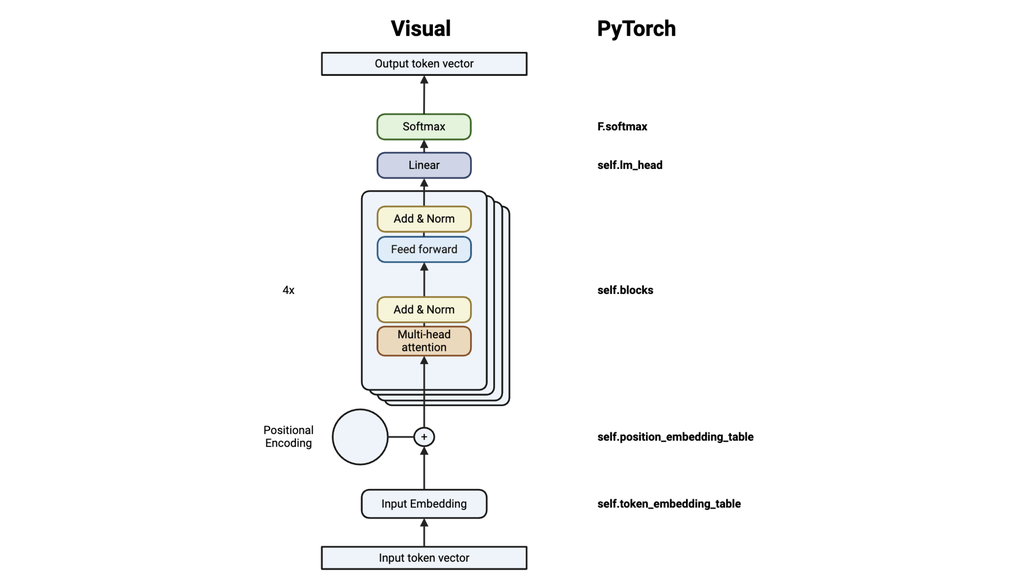

image.png

아래 모델과 GPT는 모두 트랜스포머 아키텍처를 기반으로 합니다. 몇 가지 유사점과 차이점은 다음과 같습니다: * 레이어 수: GPT 모델은 일반적으로 많은 수의 트랜스포머 블록으로 구성됩니다(GPT1에는 12개, GPT2-L에는 48개, GPT3-L에는 384개의 블록이 있음). 우리 모델에는 4개의 블록이 있습니다. * GPT는 토큰별로 텍스트를 생성합니다(여기서 토큰은 일반적으로 단어 조각임). 우리 모델은 문자별로 텍스트를 생성합니다. * GPT는 가변 길이 문맥 시퀀스를 처리합니다. 우리 모델은 고정 크기 문맥 창(블록 크기)을 취하고 이 문맥을 기반으로 다음 토큰을 생성합니다.

```python
# hyperparameters
batch_size = 16 # how many independent sequences will we process in parallel?
block_size = 32 # what is the maximum context length for predictions?
max_iters = 5000
eval_interval = 100
learning_rate = 1e-3
device = 'cuda' if torch.cuda.is_available() else 'cpu'
eval_iters = 200
n_embd = 64
n_head = 4
n_layer = 4
dropout = 0.0
# ------------
```

`estimate_loss()` 함수를 정의하여 학습 및 검증 데이터 모두에서 NN의 손실을 평가합니다. 모델은 일시적으로 평가 모드로 전환되어 그래디언트 계산을 비활성화하여 계산 효율성을 높입니다. 학습 및 검증 분할을 반복하여 데이터 배치를 검색하고 손실을 계산합니다. 각 분할에 대한 평균 손실을 계산한 후 모델은 학습 모드로 되돌아갑니다. 마지막으로 함수는 두 분할에 대한 평균 손실이 포함된 사전을 반환합니다. 이는 기계 학습 작업의 평가에 중요한 매개변수를 업데이트하지 않고 모델의 성능을 평가하는 데 도움이 됩니다.

```python
@torch.no_grad()
def estimate_loss():
    out = {}
    model.eval()
    for split in ['train', 'val']:
        losses = torch.zeros(eval_iters)
        for k in range(eval_iters):
            X, Y = get_batch(split)
            logits, loss = model(X, Y)
            losses[k] = loss.item()
        out[split] = losses.mean()
    model.train()
    return out
```

트랜스포머의 주요 성공 요인은 *어텐션(attention)*이며, 이는 `Head`와 `MultiHeadAttention`에서 정의합니다. Head 클래스는 트랜스포머 아키텍처의 기본 구성 요소인 자기 어텐션(self-attention)의 단일 헤드를 나타냅니다. 키(key), 쿼리(query), 값(value) 표현을 계산하기 위한 선형 레이어(self.key, self.query, self.value)와 마스킹을 위한 삼각형 버퍼를 초기화합니다. 순전파(forward) 메서드에서는 어텐션 점수를 계산하고, 마스킹을 적용하고, 어텐션 가중치를 계산하고, 이러한 가중치를 기반으로 값을 집계합니다.

MultiHeadAttention 클래스는 병렬로 작동하는 여러 자기 어텐션 헤드를 나타냅니다. 멀티 헤드 어텐션을 수행하기 위해 Head 인스턴스 목록(self.heads)을 생성합니다. 순전파 메서드에서는 각 헤드를 입력 텐서 x에 개별적으로 적용하고 결과를 연결하고 연결된 출력을 투영하고 정규화를 위해 드롭아웃을 적용합니다. 이 클래스를 사용하면 모델이 여러 어텐션 메커니즘을 통해 입력 데이터의 다양한 측면을 동시에 포착하여 표현 능력과 성능을 향상시킬 수 있습니다.

```python
class Head(nn.Module):
    """ one head of self-attention """

    def __init__(self, head_size):
        super().__init__()
        self.key = nn.Linear(n_embd, head_size, bias=False)
        self.query = nn.Linear(n_embd, head_size, bias=False)
        self.value = nn.Linear(n_embd, head_size, bias=False)
        self.register_buffer('tril', torch.tril(torch.ones(block_size, block_size)))

        self.dropout = nn.Dropout(dropout)

    def forward(self, x):
        B,T,C = x.shape
        k = self.key(x)   # (B,T,C)
        q = self.query(x) # (B,T,C)
        # compute attention scores ("affinities")
        wei = q @ k.transpose(-2,-1) * C**-0.5 # (B, T, C) @ (B, C, T) -> (B, T, T)
        wei = wei.masked_fill(self.tril[:T, :T] == 0, float('-inf')) # (B, T, T)
        wei = F.softmax(wei, dim=-1) # (B, T, T)
        wei = self.dropout(wei)
        # perform the weighted aggregation of the values
        v = self.value(x) # (B,T,C)
        out = wei @ v # (B, T, T) @ (B, T, C) -> (B, T, C)
        return out

class MultiHeadAttention(nn.Module):
    """ multiple heads of self-attention in parallel """

    def __init__(self, num_heads, head_size):
        super().__init__()
        self.heads = nn.ModuleList([Head(head_size) for _ in range(num_heads)])
        self.proj = nn.Linear(n_embd, n_embd)
        self.dropout = nn.Dropout(dropout)

    def forward(self, x):
        out = torch.cat([h(x) for h in self.heads], dim=-1)
        out = self.dropout(self.proj(out))
        return out
```

`FeedForward` 클래스는 트랜스포머 아키텍처에서 흔히 볼 수 있는 간단한 피드포워드 신경망 레이어를 나타냅니다. 두 개의 선형 레이어와 그 뒤를 잇는 정규화를 위한 ReLU 활성화 및 드롭아웃이 포함되어 있습니다. 순전파 메서드에서는 이러한 연산을 입력 텐서 x에 순차적으로 적용하여 고차원 공간으로 변환하고 비선형성을 도입합니다.

```python
class FeedFoward(nn.Module):
    """ a simple linear layer followed by a non-linearity """

    def __init__(self, n_embd):
        super().__init__()
        self.net = nn.Sequential(
            nn.Linear(n_embd, 4 * n_embd),
            nn.ReLU(),
            nn.Linear(4 * n_embd, n_embd),
            nn.Dropout(dropout),
        )

    def forward(self, x):
        return self.net(x)

class Block(nn.Module):
    """ Transformer block: communication followed by computation """

    def __init__(self, n_embd, n_head):
        # n_embd: embedding dimension, n_head: the number of heads we'd like
        super().__init__()
        head_size = n_embd // n_head
        self.sa = MultiHeadAttention(n_head, head_size)
        self.ffwd = FeedFoward(n_embd)
        self.ln1 = nn.LayerNorm(n_embd)
        self.ln2 = nn.LayerNorm(n_embd)

    def forward(self, x):
        x = x + self.sa(self.ln1(x))
        x = x + self.ffwd(self.ln2(x))
        return x
```

`BigramLanguageModel` 클래스는 토큰 표현을 위한 임베딩 레이어, 시퀀스 내 토큰 위치를 포착하기 위한 위치 임베딩 레이어, 입력을 처리하기 위한 트랜스포머 블록 스택, 학습 안정을 위한 레이어 정규화, 다음 토큰을 예측하기 위한 선형 레이어로 구성됩니다. 순전파 동안 모델은 토큰을 나타내는 입력 인덱스를 취하고, 임베딩 및 위치 인코딩을 적용하고, 트랜스포머 블록을 통해 처리하고, 다음 토큰의 로짓을 예측합니다. 그런 다음 손실을 계산합니다. 생성을 위해 모델은 예측된 분포에서 반복적으로 샘플링하여 이전 문맥 및 모델에서 생성된 확률을 기반으로 다음 토큰을 선택합니다. 이 접근 방식을 통해 모델은 토큰 시퀀스를 자율적으로 생성할 수 있습니다.

```python
# super simple bigram model
class BigramLanguageModel(nn.Module):

    def __init__(self):
        super().__init__()
        # each token directly reads off the logits for the next token from a lookup table
        self.token_embedding_table = nn.Embedding(vocab_size, n_embd)
        self.position_embedding_table = nn.Embedding(block_size, n_embd)
        self.blocks = nn.Sequential(*[Block(n_embd, n_head=n_head) for _ in range(n_layer)])
        self.ln_f = nn.LayerNorm(n_embd) # final layer norm
        self.lm_head = nn.Linear(n_embd, vocab_size)

    def forward(self, idx, targets=None):
        B, T = idx.shape

        # idx and targets are both (B,T) tensor of integers
        tok_emb = self.token_embedding_table(idx) # (B,T,C)
        pos_emb = self.position_embedding_table(torch.arange(T, device=device)) # (T,C)
        x = tok_emb + pos_emb # (B,T,C)
        x = self.blocks(x) # (B,T,C)
        x = self.ln_f(x) # (B,T,C)
        logits = self.lm_head(x) # (B,T,vocab_size)

        if targets is None:
            loss = None
        else:
            B, T, C = logits.shape
            logits = logits.view(B*T, C)
            targets = targets.view(B*T)
            loss = F.cross_entropy(logits, targets)

        return logits, loss

    def generate(self, idx, max_new_tokens):
        # idx is (B, T) array of indices in the current context
        for _ in range(max_new_tokens):
            # crop idx to the last block_size tokens
            idx_cond = idx[:, -block_size:]
            # get the predictions
            logits, loss = self(idx_cond)
            # focus only on the last time step
            logits = logits[:, -1, :] # becomes (B, C)
            # apply softmax to get probabilities
            probs = F.softmax(logits, dim=-1) # (B, C)
            # sample from the distribution
            idx_next = torch.multinomial(probs, num_samples=1) # (B, 1)
            # append sampled index to the running sequence
            idx = torch.cat((idx, idx_next), dim=1) # (B, T+1)
        return idx
```

모델 인스턴스화하기

```python
model = BigramLanguageModel()
m = model.to(device)
# print the number of parameters in the model
print(sum(p.numel() for p in m.parameters())/1e6, 'M parameters')

# create a PyTorch optimizer
optimizer = torch.optim.AdamW(model.parameters(), lr=learning_rate)
```

```
0.209729 M parameters
```

# **섹션 4: 학습**

코드는 max_iters 반복 횟수만큼 루프를 실행합니다. 매 eval_interval 반복마다(또는 마지막 반복에서) estimate_loss() 함수를 사용하여 학습 및 검증 세트 모두에서 손실을 평가하고 결과를 출력합니다. 그런 다음 get_batch() 함수를 사용하여 학습 세트에서 데이터 배치(xb, yb)를 샘플링합니다. 모델은 입력(xb) 및 목표(yb) 텐서로 호출되어 로짓과 손실을 계산합니다. 옵티마이저의 그래디언트는 set_to_none=True로 영(0)이 됩니다(optimizer.zero_grad()). 이는 메모리 사용을 더 효율적으로 만듭니다. 그패디언트를 계산하기 위해 역전파가 수행됩니다(loss.backward()). 마지막으로 옵티마이저는 계산된 그래디언트를 기반으로 모델 파라미터를 업데이트하기 위해 단계(optimizer.step())를 밟습니다.

```python
for iter in range(max_iters):

    # every once in a while evaluate the loss on train and val sets
    if iter % eval_interval == 0 or iter == max_iters - 1:
        losses = estimate_loss()
        print(f"step {iter}: train loss {losses['train']:.4f}, val loss {losses['val']:.4f}")

    # sample a batch of data
    xb, yb = get_batch('train')

    # evaluate the loss
    logits, loss = model(xb, yb)
    optimizer.zero_grad(set_to_none=True)
    loss.backward()
    optimizer.step()
```

```
step 0: train loss 4.4166, val loss 4.4138
step 100: train loss 2.6565, val loss 2.6660
step 200: train loss 2.5054, val loss 2.4991
step 300: train loss 2.4156, val loss 2.4250
step 400: train loss 2.3504, val loss 2.3638
step 500: train loss 2.3134, val loss 2.3332
step 600: train loss 2.2550, val loss 2.2668
step 700: train loss 2.2216, val loss 2.2324
step 800: train loss 2.1821, val loss 2.2038
step 900: train loss 2.1458, val loss 2.1676
step 1000: train loss 2.1172, val loss 2.1455
step 1100: train loss 2.0883, val loss 2.1382
step 1200: train loss 2.0587, val loss 2.1036
step 1300: train loss 2.0410, val loss 2.0769
step 1400: train loss 2.0095, val loss 2.0547
step 1500: train loss 1.9951, val loss 2.0612
step 1600: train loss 1.9671, val loss 2.0487
step 1700: train loss 1.9665, val loss 2.0399
step 1800: train loss 1.9223, val loss 2.0177
step 1900: train loss 1.9239, val loss 2.0033
step 2000: train loss 1.8967, val loss 2.0079
step 2100: train loss 1.8890, val loss 1.9935
step 2200: train loss 1.8648, val loss 1.9667
step 2300: train loss 1.8607, val loss 1.9619
step 2400: train loss 1.8465, val loss 1.9414
step 2500: train loss 1.8273, val loss 1.9546
step 2600: train loss 1.8295, val loss 1.9418
step 2700: train loss 1.8314, val loss 1.9478
step 2800: train loss 1.8072, val loss 1.9341
step 2900: train loss 1.8032, val loss 1.9350
step 3000: train loss 1.7968, val loss 1.9243
step 3100: train loss 1.7785, val loss 1.9223
step 3200: train loss 1.7684, val loss 1.9112
step 3300: train loss 1.7700, val loss 1.9143
step 3400: train loss 1.7564, val loss 1.8982
step 3500: train loss 1.7397, val loss 1.8972
step 3600: train loss 1.7348, val loss 1.8899
step 3700: train loss 1.7338, val loss 1.8860
step 3800: train loss 1.7326, val loss 1.9028
step 3900: train loss 1.7289, val loss 1.8715
step 4000: train loss 1.7228, val loss 1.8684
step 4100: train loss 1.7142, val loss 1.8763
step 4200: train loss 1.7030, val loss 1.8693
step 4300: train loss 1.7099, val loss 1.8551
step 4400: train loss 1.7138, val loss 1.8726
step 4500: train loss 1.6938, val loss 1.8540
step 4600: train loss 1.6934, val loss 1.8410
step 4700: train loss 1.6836, val loss 1.8389
step 4800: train loss 1.6751, val loss 1.8453
step 4900: train loss 1.6787, val loss 1.8463
step 4999: train loss 1.6747, val loss 1.8296
```

학습 후, 0으로 구성된 텐서인 초기 문맥(context)을 제공하여 텍스트 생성을 시연합니다. 문맥 텐서가 0으로 초기화되므로 본질적으로 텍스트 생성의 빈 시작점을 나타냅니다. 언어 모델은 이 빈 문맥을 생성된 시퀀스의 시작으로 사용하고 학습된 패턴과 제공된 문맥을 기반으로 점진적으로 토큰을 생성합니다. 토큰이 생성됨에 따라 문맥 텐서에 추가되어 모델이 진화하는 시퀀스를 기반으로 텍스트를 계속 생성할 수 있습니다.

```python
# generate from the model
# if generating proteins... if you want to see how 'protein-like' the sequences are, feed them into AlphaFold2 and see if the sequence folds!!
context = torch.zeros((1, 1), dtype=torch.long, device=device)
print(decode(m.generate(context, max_new_tokens=1000)[0].tolist()))
```

```
Why not call, Clifffay, all there me fear the labluntch but your Cappence agmand to
Too.

MONSARY:
Good
Where these bappedied Droum, to
I will depi'gr not love fellow the my breath,
Than furthon that My love tambled thy followns and the like daming this di;
And and he but thever is very may moung twict the Levings. Consticly
Me brothers gate?
Not, now you some, what that my frece fullw'd thou brother,
As my live, ashow thyself den; and is thurncts'd wher here's up?
I would loves minow. Pomfort life, shom Conty-driack: sol, and,
And,--like as may that Kingly testens can xpurthymen, shall where like
Thel, I haffit, thy not loves!
And consent the brody with in in but the carrition.
Camb'd, take His this you
ruther thine why, I'll mansce's have with a what fell wailt afwifed
God stild thou lost; as now, I have this rypengt.

LANTA:
He is not Plow; deyelf, good whither
Forth: you, would it: and thus for not
And sabetruess this let old this
As kneep ausis, trulow.--greaden of them heavy:
Whe
```

또한 더 구체적인 문맥에서 텍스트를 생성해 봅시다.

```python
# input context. Change this to whatever you want!
# if you are generating protein sequences... try inserting the first feww residues of a protein chain!
input_context = "In the house of"

# encode input
encoded_context = encode(input_context)

# input into tensor
context = torch.tensor([encoded_context], dtype=torch.long, device=device)

# generate text using context
generated_text = m.generate(context, max_new_tokens=100)[0].tolist()

# decode and print text
print(decode(generated_text))
```

```
In the house of the brow you not.

DUCHSHOMAND:
Go denemings given they Comentence,
Sincoud ir, I am your her
Water
```

## **질문**

모델의 하이퍼파라미터를 수정하고 각각이 모델의 성능에 어떤 영향을 미치는지 확인해 봅시다!

**질문**: `n_embd`(임베딩 크기)를 64에서 더 높은 값(예: 128 또는 256)으로 늘리세요. 이것이 원래 모델과 비교하여 성능에 어떤 영향을 미치나요?

```python
#@markdown <font color='#e59454'>Run to See Answer!</font>

print("\n Increasing the embedding size allows the model to capture more nuanced patterns in the data. \n A larger embedding dimension generally improves the model's capacity to understand and generate more complex language features. \n Final loss should decrease.")
```

**질문**: `n_layer`(트랜스포머 레이어 수)를 4에서 더 높은 값(예: 6 또는 8)으로 늘리세요. 이것이 모델의 성능에 어떤 영향을 미치나요?

```python
#@markdown <font color='#e59454'>Run to See Answer!</font>

print("\n More layers allow the model to learn deeper hierarchical patterns, which is important for capturing long-range dependencies in text. \n The final loss should decrease due to better capacity to model long-range dependencies.")
```

**질문**: `n_head`(어텐션 헤드 수)를 4에서 더 높은 값(예: 8 또는 16)으로 늘리세요. 이것이 모델 성능에 어떤 영향을 미치나요?

```python
#@markdown <font color='#e59454'>Run to See Answer!</font>

print("\n More attention heads allow the model to capture multiple aspects of relationships between tokens in parallel. \n Increasing the number of attention heads can improve the model’s ability to focus on different parts of the input simultaneously. \n The final loss should decrease.")
```

일반적으로 임베딩 크기, 레이어 수 또는 어텐션 헤드 수를 늘려 트랜스포머 모델을 확장하면 많은 자연어 처리 작업에서 성능이 향상되는 경향이 있습니다. 더 큰 모델은 데이터의 더 복잡한 패턴, 관계 및 의존성을 포착할 수 있는 용량이 더 크기 때문에 이러한 추세가 나타납니다. 파라미터가 많을수록 모델은 학습 데이터에서 더 잘 일반화하고 더 정확하고 일관되며 맥락적으로 풍부한 출력을 생성할 수 있습니다. 그러나 확장에 따른 이득은 특정 지점에서 감소하며, 특히 제한된 데이터나 계산 리소스 내에서는 과적합이나 비효율성을 피하기 위해 하이퍼파라미터를 신중하게 조정해야 합니다.

**관련 논문** * 언어 모델로 5억 년의 진화 시뮬레이션, Hayes et al, 2024 * ESM Cambrian: 비지도 학습으로 단백질의 신비 밝히기, 2024 * 개선된 항체 설계를 위한 항체 생식세열 편향 및 언어 모델에 미치는 영향 해결, 2024 * 단백질 언어 시각화 도구: 언어 모델 시대의 서열 유사성 네트워크, 2024 * 단백질 언어 모델 미세 조정으로 다양한 작업의 예측 향상, 2024 * 긴 문맥 단백질 언어 모델, 2024 * 학습 계산 최적 단백질 언어 모델, 2024 * 프롬프트된 언어 모델을 통한 다목적 제어 가능한 단백질 생성, 2024 * 언어 모델로 단백질 설계, 2024 * 단백질 언어 모델은 상호 작용하는 서열 모티프의 진화 통계 학습, 2024 * p-IgGen: 쌍체 항체 생성 언어 모델, 2024 * 단백질 언어 모델은 계산 최적인가?, 2024 * 특징 재사용 및 확장: 단백질 언어 모델을 통한 전이 학습 이해, 2024 * 구조 조건부 설계를 위한 단백질 언어 모델 적응, 2024 * 단백질 언어 모델에서 고차 상호 작용 복구에 관하여, 2024 * 단백질 언어 모델은 생명의 나무 전반에 걸친 불평등한 서열 샘플링으로 편향됨, 2024 * ESM All-Atom: 통합 분자 모델링을 위한 다중 스케일 단백질 언어 모델, 2024 * 단백질 유도 진화를 위한 지식 인식 강화 언어 모델, 2024 * 멀티 모달 대규모 언어 모델로 단백질 기능 예측 가능, 2024 * 다양한 다운스트림 작업에서 텍스트 통합 단백질 언어 모델 임베딩 및 임베딩 융합 벤치마킹, 2024 * 대규모 쌍체 항체 언어 모델, 2024 * 구조 정보 언어 모델을 통한 단백질 및 항체 복합체의 비지도 진화, 2024 * 기본 페어링으로 항체 언어 모델 개선, 2023 * 대규모 언어 모델은 다양한 계열에 걸쳐 기능적 단백질 서열 생성, 2023 * ProGen2: 단백질 언어 모델의 경계 탐구, 2022 * 항체 설계를 위한 생성적 언어 모델링, 2023 * 진화 규모의 단백질 서열 언어 모델로 정확한 구조 예측 가능, 2023